# A gentle introdution to tidymodels

Asmae Toumi

12/10/2021

## Packages and data

```r
library(here)
library(tidyverse)
library(janitor)
library(tidymodels)
library(rules) # for rule-based models
library(baguette) # efficient functions for bagging ensemble models
library(workflowsets) # workflow sets
library(finetune) # tuning
library(stacks) # ensembling
```

If you don’t already have these packages, install them using `pak::pak("package_name")`.

We’ll be using the [2021 World Happiness Report](https://www.kaggle.com/ajaypalsinghlo/world-happiness-report-2021) dataset, which contains information regarding the state of happiness in the world. It contains happiness scores and rankings from the Gallup World Poll, as well as additional information that can explain variations between countries in happiness:

- economic production
- social support
- life expectancy
- freedom
- absence of corruption
- generosity

```r
happiness <-
  read_csv("world-happiness-report-2021.csv") %>%
  clean_names() %>%
  select(
    ladder_score, # our outcome
    logged_gdp_per_capita,
    social_support,
    healthy_life_expectancy,
    freedom_to_make_life_choices,
    generosity,
    perceptions_of_corruption
  )
```

## Step 1: splitting

An important part of validating a model is making sure we split our data into a *training* set and a *test* set at the start. The training set is used for model development and optimization, while the test set is held out until models have been selected. The test set is then used to determine the efficacy of the models chosen.

For this dataset, we will perform:

- stratified sampling using the default 3:1 ratio of training-to-test
- resample the training set using five repeats of 10-fold cross-validation

This can be achieved using functions from the **{rsample}** packages, which creates a special “split” object.

```r
set.seed(420)

# splitting
happiness_splits <- initial_split(happiness, strata = ladder_score)
happiness_train <- training(happiness_splits)
happiness_test <- testing(happiness_splits)

# 10-fold cross validation
happiness_folds <-
  happiness_train %>%
  vfold_cv(strata = ladder_score, repeats = 5)
```

We can inspect our split object:

```r
happiness_splits
```

```
## <Analysis/Assess/Total>
## <109/40/149>
```

## Step 2: our “recipes”

The **{recipe}** package allows you to specify the role of each variable, and any pre-processing steps you will require. To set up a “recipe”:

1. **Specify the formula** using (`recipe()`): specify the role of each variable, into outcome or predictor variables
2. **Specify pre-processing steps** using (`step_*()`): define the pre-processing steps (e.g. normalization, interaction terms, principal component analysis, etc.)

In our case, we will specify **two** recipes: - Recipe 1: for models where predictors are required to be scaled and centered - Recipe 2: for models where we want to use quadratic and interaction terms

```r
# Recipe 1: normalized recipe
recipe_norm <-
  happiness_train %>%
  recipe(ladder_score ~ .) %>%
  # normalize all predictors to have SD of 1, mean of 0
  step_normalize(all_predictors())

# Recipe 2: polynomial recipe
recipe_poly <-
  recipe_norm %>%
  # create new columns that are basis expansions of variables using orthogonal polynomials
  step_poly(all_predictors()) %>%
  # create new columns that are interaction terms between all variables
  step_interact(~ all_predictors():all_predictors())
```

We made use of a few helper functions:

- `outcome ~ .` will fit a model that predicts the outcome using *all* other columns.
- `all_predictors()` is a role selector which allows us to apply our `step_*` to all predictor variables

We can inspect the summary of our “recipes”:

```r
recipe_norm
```

```
## Recipe
##
## Inputs:
##
##       role #variables
##    outcome          1
##  predictor          6
##
## Operations:
##
## Centering and scaling for all_predictors()
```

```r
recipe_poly
```

```
## Recipe
##
## Inputs:
##
##       role #variables
##    outcome          1
##  predictor          6
##
## Operations:
##
## Centering and scaling for all_predictors()
## Orthogonal polynomials on all_predictors()
## Interactions with all_predictors():all_predictors()
```

## Step 3: specify the models

The next step is to specify our models using the **{parsnip}** package. The **{parsnip}** package is a unified interface for model selection and specification. For model selection and specification, you need:

- The **model type**: the model desired, e.g. `rand_forest()` for a random forest, `linear_reg()` for linear regression, `nearest_neighbor()` for K-nearest neighbor, and so on. There is an incredible add-in to browse these models and copy them in to your script.
- The **engine**: the underlying package the model should come from (e.g. “ranger” for the ranger implementation of Random Forest), set using `set_engine()`.
- The **mode**: the type of prediction (e.g. classification or regression), set using `set_mode()`.

```r
# glmnet (glm via penalized maximum likelihood)
spec_lr <-
  linear_reg(penalty = tune(), mixture = tune()) %>%
  set_engine('glmnet')

# MARS (multivariate adaptive regression splines)
spec_mars <-
  mars(prod_degree = tune()) %>%
  set_engine('earth') %>%
  set_mode("regression")

# SVM (support vector machines) - radial basis function
spec_svm_r <-
  svm_rbf(cost = tune(), rbf_sigma = tune()) %>%
  set_engine('kernlab') %>%
  set_mode("regression")

# SVM (support vector machines) - polynomial
spec_svm_p <-
  svm_poly(cost = tune(), degree = tune()) %>%
  set_engine('kernlab') %>%
  set_mode("regression")

# K-Nearest Neighbor
spec_knn <-
  nearest_neighbor(
    neighbors = tune(),
    dist_power = tune(),
    weight_func = tune()
  ) %>%
  set_engine('kknn') %>%
  set_mode("regression")

# CART (classification and regression tree)
spec_cart <-
  decision_tree(cost_complexity = tune(), min_n = tune()) %>%
  set_engine('rpart') %>%
  set_mode("regression")

# Bagged decision trees
spec_cart_bag <-
  bag_tree() %>%
  set_engine('rpart', times = 50L) %>%
  set_mode("regression")

# Random forest
spec_rf <-
  rand_forest(mtry = tune(), min_n = tune(), trees = 200L) %>%
  set_engine('ranger') %>%
  set_mode("regression")

# XGBoost (eXtreme Gradient Boosting)
spec_xgb <-
  boost_tree(
    tree_depth = tune(),
    learn_rate = tune(),
    loss_reduction = tune(),
    min_n = tune(),
    sample_size = tune(),
    trees = 200L
  ) %>%
  set_engine('xgboost') %>%
  set_mode("regression")

# cubist rule-based regression
spec_cube <-
  cubist_rules(committees = tune(), neighbors = tune()) %>%
  set_engine('Cubist')
```

## Step 4: putting it all together

Now we’ll put the model and recipes together into workflow sets. You initiate a workflow set using `workflow_set()` (from the **{workflowsets}** package) and then adding the recipes and models to it.

In our example, we will be:

- Creating workflowsets for our 3 recipes:
  - workflowset 1: for the models using `recipe_norm`
  - workflowset 2: for the models using `recipe_poly`
  - workflowset 3: for the models not requiring any preprocessing steps
- Combining all workflow sets above into one single workflowsets object

```r
sets_norm <-
  workflow_set(
    preproc = list(norm = recipe_norm),
    models = list(
      svm_r = spec_svm_r,
      svm_p = spec_svm_p,
      knn = spec_knn
    )
  )

sets_poly <-
  workflow_set(
    preproc = list(norm = recipe_poly),
    models = list(lr = spec_lr, knn = spec_knn)
  )

# several recipes don't need pre-processing
# need to have a `preproc` step to use `workflowsets::workflow_variables()`

sets_simple <-
  workflow_set(
    preproc = list(formula(ladder_score ~.)),
    models =
      list(
        mars = spec_mars,
        cart = spec_cart,
        cart_bag = spec_cart_bag,
        rf = spec_rf,
        gb = spec_xgb,
        cube = spec_cube
      )
  )

sets <- bind_rows(sets_norm, sets_poly, sets_simple)

sets
```

```
## # A tibble: 11 × 4
##    wflow_id         info             option    result
##    <chr>            <list>           <list>    <list>
##  1 norm_svm_r       <tibble [1 × 4]> <opts[0]> <list [0]>
##  2 norm_svm_p       <tibble [1 × 4]> <opts[0]> <list [0]>
##  3 norm_knn         <tibble [1 × 4]> <opts[0]> <list [0]>
##  4 norm_lr          <tibble [1 × 4]> <opts[0]> <list [0]>
##  5 norm_knn         <tibble [1 × 4]> <opts[0]> <list [0]>
##  6 formula_mars     <tibble [1 × 4]> <opts[0]> <list [0]>
##  7 formula_cart     <tibble [1 × 4]> <opts[0]> <list [0]>
##  8 formula_cart_bag <tibble [1 × 4]> <opts[0]> <list [0]>
##  9 formula_rf       <tibble [1 × 4]> <opts[0]> <list [0]>
## 10 formula_gb       <tibble [1 × 4]> <opts[0]> <list [0]>
## 11 formula_cube     <tibble [1 × 4]> <opts[0]> <list [0]>
```

## Step 5: tuning

Since we have several models with parameters that we specified needed to be turned, we need to tune them to determine which parameter values lead to the best model performances before fitting our models. If we had selected models without any parameters to tune, we could have skipped this process.

In our example, we will be performing grid search via racing approach (more efficient, see [Section 13.4.4](https://www.tmwr.org/grid-search.html#racing)) using up to 100 different parameter candidates.

```r
ctrl_race <-
  control_race(
    save_pred = TRUE,
    parallel_over = 'everything',
    save_workflow = TRUE
  )

res_grid <-
  sets %>%
  workflow_map(
    'tune_race_anova',
    seed = 420,
    resamples = happiness_folds,
    grid = 100,
    control = ctrl_race,
    verbose = TRUE
  )
```

## Step 6: evaluate cross-validation performance

We will be assessing cross-validation performance by:

- using `rank_results()` from **{workflowsets}** to rank models by root mean square error (RMSE)
- using `select_best()` from **{tune}** inside `autoplot()` to rank models using their best tuning parameter combination

```r
res_ranks <-
  res_grid %>%
  rank_results('rmse') %>%
  filter(.metric == 'rmse') %>%
  select(wflow_id, model, .config, rmse = mean, rank) %>%
  group_by(model) %>%
  slice_min(rank, with_ties = FALSE) %>%
  ungroup() %>%
  arrange(rank)

res_ranks
```

```
## # A tibble: 10 × 5
##    wflow_id         model            .config                 rmse  rank
##    <chr>            <chr>            <chr>                  <dbl> <int>
##  1 norm_svm_p       svm_poly         Preprocessor1_Model059 0.524     1
##  2 formula_rf       rand_forest      Preprocessor1_Model70  0.527     2
##  3 formula_gb       boost_tree       Preprocessor1_Model089 0.535    19
##  4 norm_svm_r       svm_rbf          Preprocessor1_Model084 0.543    35
##  5 formula_knn      nearest_neighbor Preprocessor1_Model086 0.553    63
##  6 formula_cube     cubist_rules     Preprocessor1_Model43  0.558   127
##  7 formula_lr       linear_reg       Preprocessor1_Model011 0.563   175
##  8 formula_cart_bag bag_tree         Preprocessor1_Model1   0.565   183
##  9 formula_mars     mars             Preprocessor1_Model1   0.606   472
## 10 formula_cart     decision_tree    Preprocessor1_Model007 0.639   473
```

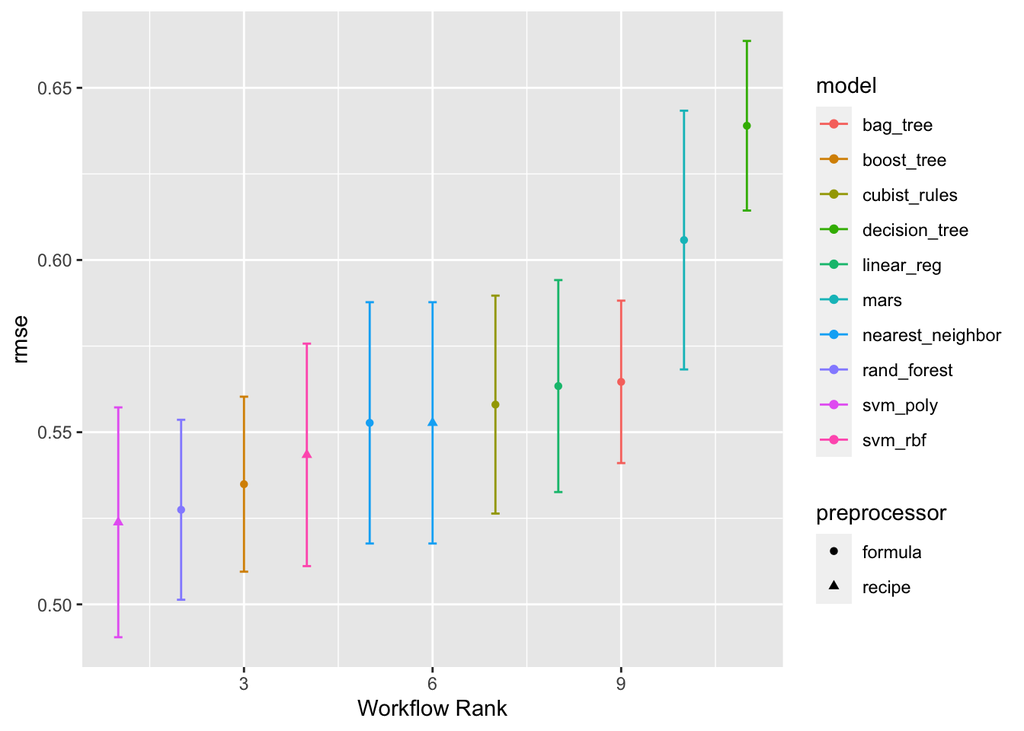

```r
autoplot(
  res_grid,
  rank_metric = "rmse",
  metric = "rmse",
  select_best = TRUE
  )
```

## Step 7: evaluate performance on test set

The final steps involve choosing the best model and evaluating its performance on the test set by:

- using `pull_workflow_set_result()` from **{workflowsets}** to extract the best workflow
- using `finalize_workflow()` and `last_fit()` from **{tune}** to fit on the full training set
- using `collect_metrics()` from **{tune}** to see results on the test set
- using `collect_predictions()` from **{tune}** to extract the test set predictions

```r
wflow_id_best <-
  res_ranks %>%
  slice_min(rank, with_ties = FALSE) %>%
  pull(wflow_id)

wflow_id_best
```

```
## [1] "norm_svm_p"
```

```r
wf_best <-
  res_grid %>%
  pull_workflow_set_result(wflow_id_best) %>%
  select_best(metric = 'rmse')
wf_best
```

```
## # A tibble: 1 × 3
##     cost degree .config
##    <dbl>  <int> <chr>
## 1 0.0272      2 Preprocessor1_Model059
```

```r
fit_best <-
  res_grid %>%
  pull_workflow(wflow_id_best) %>%
  finalize_workflow(wf_best) %>%
  last_fit(split = happiness_splits)
# test set results
metrics_best <-
  fit_best %>%
  collect_metrics()

metrics_best
```

```
## # A tibble: 2 × 4
##   .metric .estimator .estimate .config
##   <chr>   <chr>          <dbl> <chr>
## 1 rmse    standard       0.530 Preprocessor1_Model1
## 2 rsq     standard       0.777 Preprocessor1_Model1
```

```r
fit_best %>%
  collect_predictions() # same number of rows as the test set
```

```
## # A tibble: 40 × 5
##    id               .pred  .row ladder_score .config
##    <chr>            <dbl> <int>        <dbl> <chr>
##  1 train/test split  7.54     2         7.62 Preprocessor1_Model1
##  2 train/test split  7.21    10         7.27 Preprocessor1_Model1
##  3 train/test split  7.26    11         7.18 Preprocessor1_Model1
##  4 train/test split  7.16    14         7.10 Preprocessor1_Model1
##  5 train/test split  7.50    15         7.08 Preprocessor1_Model1
##  6 train/test split  6.61    20         6.83 Preprocessor1_Model1
##  7 train/test split  5.62    30         6.44 Preprocessor1_Model1
##  8 train/test split  7.41    32         6.38 Preprocessor1_Model1
##  9 train/test split  5.82    35         6.33 Preprocessor1_Model1
## 10 train/test split  5.93    36         6.32 Preprocessor1_Model1
## # … with 30 more rows
```

## Your turn

Using the Ames dataset in the previous lab, fit a generalized linear model.

Considerations:

- What predictors are you interested in?
- What kind of preprocessing do you want to perform on your outcome and predictors?
- What splitting ratio and resampling technique will you use?

Once you’ve answered the above, generate a “skeleton” of steps for your analysis. Then, fit your linear model, and judge model effectiveness.

## Step 8: stack ’em (optional!)

**{stacks}** is a tidymodels package for ensembling, a process that involves “combining” the output of many candidate models to generate a new model, which often has superior predictive performance.

The “combining” of the candidate models involves fitting a regularized linear model to the predictions of the candidate models. Essentially, the outputs of the candidate models serve as predictors for the true outcome variable.

Each candidate model has a stacking coefficient. The higher the stacking coefficient, the more influential that candidate member’s predictions will be in the ensemble’s predictions. If the stacking coefficient is zero, it is not retained.

Implementation-wise, the flow is the following:

1. Define candidate ensemble members
2. Collect candidates
3. Initialize a *data_stack* object with `stacks()`
4. Iteratively adding candidate ensemble members to the *data_stack* with `add_candidates()`
5. Evaluate how to combine their predictions with `blend_predictions()`
6. Fit candidate ensemble members with non-zero stacking coefficients with `fit_members()`
7. Predict on new data with `predict()`

From [Simon Couch](https://twitter.com/simonpcouch)’s {stacks} [talk](https://www.youtube.com/watch?v=HZXZxvdpDOg&t=2160s):

[figure not shown]

Let’s go through the remaining steps:

- initialize the stack with `stacks()`
- add the candidate models with `add_candidates()`

```r
happiness_data_st <-
  stacks() %>%
  add_candidates(res_grid)
```

- “combine” the predictions of the *data stack* with `blend_predictions()`
- fit the candidates with non-zero stacking coefficients on the full training set

```r
happiness_model_st <-
  happiness_data_st %>%
  blend_predictions()

happiness_model_st <-
  happiness_model_st %>%
  fit_members()
```

- get predictions with `predict()`

```r
happiness_test <-
  happiness_test %>%
  bind_cols(predict(happiness_model_st, .))
```

```r
member_preds <-
  happiness_test %>%
  select(ladder_score) %>%
  bind_cols(predict(happiness_model_st, happiness_test, members = TRUE))

  map_dfr(member_preds, rmse, truth = ladder_score, data = member_preds) %>%
  mutate(member = colnames(member_preds))
```

```
## # A tibble: 12 × 4
##    .metric .estimator .estimate member
##    <chr>   <chr>          <dbl> <chr>
##  1 rmse    standard       0     ladder_score
##  2 rmse    standard       0.481 .pred
##  3 rmse    standard       0.500 norm_svm_r_1_032
##  4 rmse    standard       0.516 norm_svm_p_1_064
##  5 rmse    standard       0.518 norm_svm_p_1_012
##  6 rmse    standard       0.553 norm_svm_p_1_081
##  7 rmse    standard       0.553 norm_svm_p_1_083
##  8 rmse    standard       0.542 norm_knn_1_013
##  9 rmse    standard       0.497 norm_knn_1_072
## 10 rmse    standard       0.542 formula_knn_1_013
## 11 rmse    standard       0.581 formula_cart_1_001
## 12 rmse    standard       0.551 formula_gb_1_089
```

The stacked ensemble outperforms each of the member models.

## References

- [Tidy Modeling with R](https://www.tmwr.org) by Max Kuhn and Julia Silge
- [Tidymodels: tidy machine learning in R](https://www.rebeccabarter.com/blog/2020-03-25_machine_learning/) by Rebecca Barter
- Tony El Habr, r4ds tidymodeling with R bookclub
- [A Gentle Introduction to Tidy Model Stacking](https://blog--simonpcouch.netlify.app/blog/gentle-intro-stacks/) by Simon Couch